# Urban and Rural Museums

George Alexander Wright

2025-03-12

**Setup Information**

# Contents

- Urban-Rural Classifications
  - English and Welsh Classifications
  - Scottish Classifications
  - Northern Irish Classification
  - Composite UK-Wide Classifications
  - Spatial Signatures
- Museums in Urban and Rural Areas
  - Museums across the English and Welsh Rural/Urban Categories
  - Museums across the Scottish Rural/Urban Categories
  - Museums across the Northern Irish Rural/Urban Categories
  - Museums across the Composite UK Rural/Urban Categories
  - Museums across the Spatial Signatures
- Museums by Region
- Museum Types in Urban and Rural Areas

## Urban-Rural Classifications

There are several urban/rural classification schemes for different parts of the UK. Official classifications exist for England and Wales, Scotland, and Northern Ireland. These classify areas based on the population of settlement they are part of and the distance in driving time to the nearest major settlement.

MySociety has produced a single UK-wide set of classifications that incorporates these. It classifies areas as either urban, rural, or more rural.

Spatial Signatures classify different levels of urbanity across Great Britain, showing the differences within urban areas.

### English and Welsh Classifications

These classifications describe areas according to data from 2021

|  | rural_urban_class_england_wales | total_population | total_area_sqkm | population_percentage | area_percentage |
| --- | --- | --- | --- | --- | --- |
| 1 | Urban: Nearer to a major town or city | 45777748 | 20802 | 76 | 14.1 |
| 2 | Urban: Further from a major town or city | 4045185 | 4126 | 6.7 | 2.8 |
| 3 | Larger rural: Nearer to a major town or city | 3618638 | 11903 | 6 | 8.1 |
| 4 | Larger rural: Further from a major town or city | 1728925 | 8979 | 2.9 | 6.1 |
| 5 | Smaller rural: Nearer to a major town or city | 2977053 | 43560 | 4.9 | 29.5 |
| 6 | Smaller rural: Further from a major town or city | 2097669 | 58422 | 3.5 | 39.5 |

### Scottish Classifications

These classifications describe areas according to data from 2022

|  | rural_urban_class_scotland | total_population | total_area_sqkm | population_percentage | area_percentage |
| --- | --- | --- | --- | --- | --- |
| 1 | Large Urban Areas | 2224862 | 671 | 40.9 | 0.9 |
| 2 | Other Urban Areas | 1690575 | 1656 | 31.1 | 2.2 |
| 3 | Accessible Small Towns | 534092 | 1432 | 9.8 | 1.9 |
| 4 | Remote Small Towns | 30485 | 42 | 0.6 | 0.1 |
| 5 | Very Remote Small Towns | 75130 | 65 | 1.4 | 0.1 |
| 6 | Accessible Rural | 637393 | 26247 | 11.7 | 34.1 |
| 7 | Remote Rural | 102516 | 17585 | 1.9 | 22.9 |
| 8 | Very Remote Rural | 144512 | 29219 | 2.7 | 38 |

### Northern Irish Classifications

These classifications describe areas according to data from 2015.

|  | rural_urban_class_northern_ireland | total_population | total_area_sqkm | population_percentage | area_percentage |
| --- | --- | --- | --- | --- | --- |
| 1 | Mixed urban/rural, Accessible | 168841 | 1470 | 8.8 | 10.4 |
| 2 | Mixed urban/rural, Remote | 4214 | 176 | 0.2 | 1.2 |
| 3 | Rural, Accessible | 567784 | 9710 | 29.7 | 68.8 |
| 4 | Rural, Remote | 76229 | 2141 | 4 | 15.2 |
| 5 | Urban, Accessible | 1087387 | 618 | 56.9 | 4.4 |
| 6 | Urban, Remote | 6123 | 7 | 0.3 | 0 |

### Composite UK-wide classifications

Following the MySociety approach to building composite UK-wide rural-urban classifications, UK-wide composite classifications can also be built incorporating the more recent English, Welsh, and Scottish classifications. An additional 6-fold classification is also shown below. These are built according to the table below. English and Welsh and Scottish classifications can be straightforwardly mapped onto a UK-wide class. The MySociety approach to assigning Northern Irish SOAs a UK-wide class is not based on the default Northern Irish classifications but instead on the average settlement band of each SOA’s constituent SA (small area). SOAs that contain mostly SAs belonging to larger settlements (A-D) are classed as urban, those that contain mostly SAs belonging to smaller settlements are rural (bands E and F) or more rural (bands G and H).

| 6-fold | 3-fold | 2-fold | England/Wales class | Scotland class | Northern Ireland class |
| --- | --- | --- | --- | --- | --- |
| Urban, Accessible | Urban | Urban | Urban: Nearer… | Large Urban Areas | A,B,C,D |
| Urban, Remote | Urban | Urban | Urban: Further… | Other Urban Areas | A,B,C,D; >30mins to nearest town |
| Quite Rural, Accessible | Quite Rural | Rural | Larger rural: Nearer… | Accessible Small Towns | E,F |
| Quite Rural, Remote | Quite Rural | Rural | Larger rural: Further… | Remote Small Towns | E,F; >30mins to nearest town |
| Very Rural, Accessible | Very Rural | Rural | Smaller rural: Nearer… | Accessible Rural | G,H |
| Very Rural, Remote | Very Rural | Rural | Smaller rural: Further… | Remote Rural | G,H; >30mins to nearest town |

The term “quite rural” is used in this 3-fold system instead of MySociety’s “rural” in order to keep it distinct from the broader “rural” class within the 2-fold system.

|  | ruc_composite_6_fold | total_population | total_area_sqkm | population_percentage | area_percentage |
| --- | --- | --- | --- | --- | --- |
| 1 | Urban, Accessible | 49050159 | 22212 | 72.6 | 9.3 |
| 2 | Urban, Remote | 5735760 | 5782 | 8.5 | 2.4 |
| 3 | Quite Rural, Accessible | 4383596 | 14085 | 6.5 | 5.9 |
| 4 | Quite Rural, Remote | 1844877 | 9269 | 2.7 | 3.9 |
| 5 | Very Rural, Accessible | 4160043 | 80116 | 6.2 | 33.5 |
| 6 | Very Rural, Remote | 2420926 | 107367 | 3.6 | 45 |

|  | ruc_composite_3_fold | total_population | total_area_sqkm | population_percentage | area_percentage |
| --- | --- | --- | --- | --- | --- |
| 1 | Urban | 54785919 | 27994 | 81 | 11.7 |
| 2 | Quite Rural | 6228473 | 23354 | 9.2 | 9.8 |
| 3 | Very Rural | 6580969 | 187483 | 9.7 | 78.5 |

|  | ruc_composite_2_fold | total_population | total_area_sqkm | population_percentage | area_percentage |
| --- | --- | --- | --- | --- | --- |
| 1 | Urban | 54785919 | 27994 | 81 | 11.7 |
| 2 | Rural | 12809442 | 210837 | 19 | 88.3 |

### Spatial Signatures

Spatial Signatures classify areas along a 16-point scale from Hyper Concentrated Urbanity to Wild Countryside. This scale allows a distinction to be drawn between different levels of urban density, suburbia, and countryside. The spatial signatures only classify areas within Great Britain (England, Scotland, and Wales).

|  | spatial_signature_type | total_population | population_percentage | total_area_sqkm | area_percentage |
| --- | --- | --- | --- | --- | --- |
| 1 | Hyper concentrated urbanity | 7868 | 0.01 | 2 | 0 |
| 2 | Concentrated urbanity | 43121 | 0.07 | 8 | 0 |
| 3 | Metropolitan urbanity | 124583 | 0.19 | 15 | 0.01 |
| 4 | Regional urbanity | 876428 | 1.33 | 76 | 0.03 |
| 5 | Local urbanity | 2380837 | 3.63 | 216 | 0.09 |
| 6 | Dense urban neighbourhoods | 4128920 | 6.29 | 535 | 0.23 |
| 7 | Dense residential neighbourhoods | 5002217 | 7.62 | 872 | 0.38 |
| 8 | Connected residential neighbourhoods | 3364091 | 5.12 | 475 | 0.21 |
| 9 | Gridded residential quarters | 1722739 | 2.62 | 220 | 0.1 |
| 10 | Warehouse/Park land | 4667586 | 7.11 | 2314 | 1.01 |

[output cut: 6 more lines]

There is clear correlation between rural/urban classifications and spatial signatures. But spatial signatures allow for finer grained distinction between areas, especially those within urban settlements.

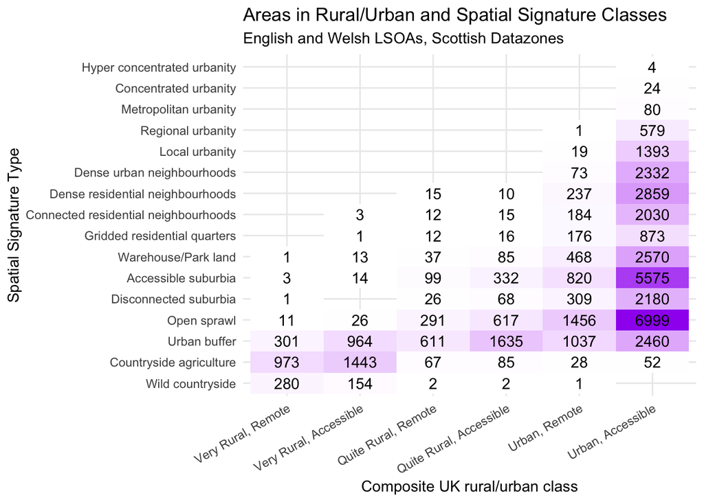

## Museums in Urban and Rural Areas

### Museums across the English and Welsh Rural/Urban Categories

|  | Rural/Urban Class | Population (millions) | Population (%) | Area (sqkm) | Area (%) | Museums (N) | Museums (%) | Museums (per 100k residents) | Z-score (per 100k residents) | Museums (per 100 sqkm) | Z-score (per 100 sqkm) |
| --- | --- | --- | --- | --- | --- | --- | --- | --- | --- | --- | --- |
| 1 | Larger rural | 5.35 | 8.9 | 20882 | 14.1 | 451 | 16.48 | 8.43 | [0.08] | 2.16 | [-0.31] |
| 2 | Smaller rural | 5.07 | 8.4 | 101982 | 69 | 630 | 23.02 | 12.41 | [0.96] | 0.62 | [-0.81] |
| 3 | Urban | 49.82 | 82.7 | 24928 | 16.9 | 1656 | 60.5 | 3.32 | [-1.04] | 6.64 | [1.12] |

|  | Rural/Urban Class | Population (millions) | Population (%) | Area (sqkm) | Area (%) | Museums (N) | Museums (%) | Museums (per 100k residents) | Z-score (per 100k residents) | Museums (per 100 sqkm) | Z-score (per 100 sqkm) |
| --- | --- | --- | --- | --- | --- | --- | --- | --- | --- | --- | --- |
| 1 | Urban | 49.82 | 82.7 | 24928 | 16.9 | 1656 | 60.5 | 3.32 | [-1.04] | 6.64 | [1.12] |
| 2 | Urban: Nearer to a major town or city | 45.78 | 76 | 20802 | 14.1 | 1375 | 50.24 | 3 | [-1.29] | 6.61 | [1.2] |
| 3 | Urban: Further from a major town or city | 4.05 | 6.7 | 4126 | 2.8 | 281 | 10.27 | 6.95 | [-0.48] | 6.81 | [1.27] |
| 4 | Larger rural | 5.35 | 8.9 | 20882 | 14.1 | 451 | 16.48 | 8.43 | [0.08] | 2.16 | [-0.31] |
| 5 | Larger rural: Nearer to a major town or city | 3.62 | 6 | 11903 | 8.1 | 202 | 7.38 | 5.58 | [-0.76] | 1.7 | [-0.53] |
| 6 | Larger rural: Further from a major town or city | 1.73 | 2.9 | 8979 | 6.1 | 249 | 9.1 | 14.4 | [1.07] | 2.77 | [-0.15] |
| 7 | Smaller rural | 5.07 | 8.4 | 101982 | 69 | 630 | 23.02 | 12.41 | [0.96] | 0.62 | [-0.81] |
| 8 | Smaller rural: Nearer to a major town or city | 2.98 | 4.9 | 43560 | 29.5 | 322 | 11.76 | 10.82 | [0.33] | 0.74 | [-0.86] |
| 9 | Smaller rural: Further from a major town or city | 2.1 | 3.5 | 58422 | 39.5 | 308 | 11.25 | 14.68 | [1.13] | 0.53 | [-0.94] |
| 10 | All | 60.25 | 100 | 147792 | 100 | 2737 | 100 | 4.54 | [None] | 1.85 | [None] |

### Museums across the Scottish Rural/Urban Categories

|  | Rural/Urban Class | Population (millions) | Population (%) | Area (sqkm) | Area (%) | Museums (N) | Museums (%) | Museums (per 100k residents) | Z-score (per 100k residents) | Museums (per 100 sqkm) | Z-score (per 100 sqkm) |
| --- | --- | --- | --- | --- | --- | --- | --- | --- | --- | --- | --- |
| 1 | Urban | 3.92 | 72 | 2327 | 3 | 215 | 41.03 | 5.49 | [-0.82] | 9.24 | [1.01] |
| 2 | Large Urban Areas | 2.22 | 40.9 | 671 | 0.9 | 108 | 20.61 | 4.85 | [-0.86] | 16.1 | [0.92] |
| 3 | Other Urban Areas | 1.69 | 31.1 | 1656 | 2.2 | 107 | 20.42 | 6.33 | [-0.79] | 6.46 | [-0.2] |
| 4 | Small Towns | 0.64 | 11.8 | 1539 | 2 | 72 | 13.74 | 11.26 | [-0.3] | 4.68 | [-0.02] |
| 5 | Accessible Small Towns | 0.53 | 9.8 | 1432 | 1.9 | 51 | 9.73 | 9.55 | [-0.64] | 3.56 | [-0.53] |
| 6 | Remote Small Towns | 0.03 | 0.6 | 42 | 0.1 | 7 | 1.34 | 22.96 | [-0.01] | 16.67 | [0.98] |
| 7 | Very Remote Small Towns | 0.08 | 1.4 | 65 | 0.1 | 14 | 2.67 | 18.63 | [-0.21] | 21.54 | [1.55] |
| 8 | Rural | 0.88 | 16.3 | 73051 | 95 | 237 | 45.23 | 26.8 | [1.11] | 0.32 | [-0.99] |
| 9 | Accessible Rural | 0.64 | 11.7 | 26247 | 34.1 | 99 | 18.89 | 15.53 | [-0.36] | 0.38 | [-0.9] |
| 10 | Remote Rural | 0.1 | 1.9 | 17585 | 22.9 | 40 | 7.63 | 39.02 | [0.75] | 0.23 | [-0.92] |

[output cut: 2 more lines]

### Museums across the Northern Irish Rural/Urban Categories

|  | Rural/Urban Class | Population (millions) | Population (%) | Area (sqkm) | Area (%) | Museums (N) | Museums (%) | Museums (per 100k residents) | Z-score (per 100k residents) | Museums (per 100 sqkm) | Z-score (per 100 sqkm) |
| --- | --- | --- | --- | --- | --- | --- | --- | --- | --- | --- | --- |
| 1 | Urban | 1.09 | 57.2 | 625 | 4.4 | 52 | 54.74 | 4.76 | [0.09] | 8.32 | [1.15] |
| 2 | Urban, Accessible | 1.09 | 56.9 | 618 | 4.4 | 52 | 54.74 | 4.78 | [-0.27] | 8.41 | [2.04] |
| 3 | Urban, Remote | 0.01 | 0.3 | 7 | 0 | 0 | 0 | 0 | [-0.84] | 0 | [-0.49] |
| 4 | Mixed urban/rural | 0.17 | 9.1 | 1646 | 11.7 | 6 | 6.32 | 3.47 | [-1.04] | 0.36 | [-0.57] |
| 5 | Mixed urban/rural, Accessible | 0.17 | 8.8 | 1470 | 10.4 | 5 | 5.26 | 2.96 | [-0.49] | 0.34 | [-0.39] |
| 6 | Mixed urban/rural, Remote | 0 | 0.2 | 176 | 1.2 | 1 | 1.05 | 23.73 | [1.98] | 0.57 | [-0.32] |
| 7 | Rural | 0.64 | 33.7 | 11851 | 83.9 | 37 | 38.95 | 5.75 | [0.95] | 0.31 | [-0.58] |
| 8 | Rural, Accessible | 0.57 | 29.7 | 9710 | 68.8 | 33 | 34.74 | 5.81 | [-0.15] | 0.34 | [-0.39] |
| 9 | Rural, Remote | 0.08 | 4 | 2141 | 15.2 | 4 | 4.21 | 5.25 | [-0.22] | 0.19 | [-0.44] |
| 10 | All | 1.91 | 100 | 14122 | 100 | 95 | 100 | 4.97 | [None] | 0.67 | [None] |

### Museums across the Composite UK Rural/Urban Categories

|  | Rural/Urban Class | Population (millions) | Population (%) | Area (sqkm) | Area (%) | Museums (N) | Museums (%) | Museums (per 100k residents) | Z-score (per 100k residents) | Museums (per 100 sqkm) | Z-score (per 100 sqkm) |
| --- | --- | --- | --- | --- | --- | --- | --- | --- | --- | --- | --- |
| 1 | Urban | 54.79 | 81 | 27994 | 11.7 | 1923 | 57.3 | 3.51 | [-0.99] | 6.87 | [1.11] |
| 2 | Urban, Accessible | 49.05 | 72.6 | 22212 | 9.3 | 1535 | 45.74 | 3.13 | [-1.17] | 6.91 | [1.26] |
| 3 | Urban, Remote | 5.74 | 8.5 | 5782 | 2.4 | 388 | 11.56 | 6.76 | [-0.55] | 6.71 | [1.19] |
| 4 | Quite Rural | 6.23 | 9.2 | 23354 | 9.8 | 530 | 15.79 | 8.51 | [-0.01] | 2.27 | [-0.28] |
| 5 | Quite Rural, Accessible | 4.38 | 6.5 | 14085 | 5.9 | 259 | 7.72 | 5.91 | [-0.7] | 1.84 | [-0.48] |
| 6 | Quite Rural, Remote | 1.84 | 2.7 | 9269 | 3.9 | 271 | 8.08 | 14.69 | [0.8] | 2.92 | [-0.1] |
| 7 | Very Rural | 6.58 | 9.7 | 187483 | 78.5 | 903 | 26.91 | 13.72 | [1.01] | 0.48 | [-0.83] |
| 8 | Very Rural, Accessible | 4.16 | 6.2 | 80116 | 33.5 | 453 | 13.5 | 10.89 | [0.15] | 0.57 | [-0.91] |
| 9 | Very Rural, Remote | 2.42 | 3.6 | 107367 | 45 | 450 | 13.41 | 18.59 | [1.47] | 0.42 | [-0.96] |
| 10 | All | 67.6 | 100 | 238831 | 100 | 3356 | 100 | 4.96 | [None] | 1.41 | [None] |

|  | Rural/Urban Class | Population (millions) | Population (%) | Area (sqkm) | Area (%) | Museums (N) | Museums (%) | Museums (per 100k residents) | Z-score (per 100k residents) | Museums (per 100 sqkm) | Z-score (per 100 sqkm) |
| --- | --- | --- | --- | --- | --- | --- | --- | --- | --- | --- | --- |
| 1 | Urban | 54.79 | 81 | 27994 | 11.7 | 1923 | 57.3 | 3.51 | [-0.99] | 6.87 | [1.11] |
| 2 | Quite Rural | 6.23 | 9.2 | 23354 | 9.8 | 530 | 15.79 | 8.51 | [-0.01] | 2.27 | [-0.28] |
| 3 | Very Rural | 6.58 | 9.7 | 187483 | 78.5 | 903 | 26.91 | 13.72 | [1.01] | 0.48 | [-0.83] |
| 4 | All | 67.6 | 100 | 238831 | 100 | 3356 | 100 | 4.96 | [None] | 1.41 | [None] |

|  | Rural/Urban Class | Population (millions) | Population (%) | Area (sqkm) | Area (%) | Museums (N) | Museums (%) | Museums (per 100k residents) | Z-score (per 100k residents) | Museums (per 100 sqkm) | Z-score (per 100 sqkm) |
| --- | --- | --- | --- | --- | --- | --- | --- | --- | --- | --- | --- |
| 1 | Urban | 54.79 | 81 | 27994 | 11.7 | 1923 | 57.3 | 3.51 | [-0.71] | 6.87 | [0.71] |
| 2 | Rural | 12.81 | 19 | 210837 | 88.3 | 1433 | 42.7 | 11.19 | [0.71] | 0.68 | [-0.71] |
| 3 | All | 67.6 | 100 | 238831 | 100 | 3356 | 100 | 4.96 | [None] | 1.41 | [None] |

### Museums across the Spatial Signatures

|  | Spatial Signature Type | Population (millions) | Population (%) | Area (sqkm) | Area (%) | Museums (N) | Museums (%) | Museums (per 100k residents) | Z-score (per 100k residents) | Museums (per 100 sqkm) | Z-score (per 100 sqkm) |
| --- | --- | --- | --- | --- | --- | --- | --- | --- | --- | --- | --- |
| 1 | Hyper concentrated urbanity | 0.01 | 0.01 | 2 | 0 | 5 | 0.15 | 63.55 | [1.54] | 250 | [0.96] |
| 2 | Concentrated urbanity | 0.04 | 0.07 | 8 | 0 | 43 | 1.32 | 99.72 | [2.82] | 537.5 | [2.76] |
| 3 | Metropolitan urbanity | 0.12 | 0.19 | 15 | 0.01 | 56 | 1.71 | 44.95 | [0.88] | 373.33 | [1.73] |
| 4 | Regional urbanity | 0.88 | 1.33 | 76 | 0.03 | 135 | 4.13 | 15.4 | [-0.16] | 177.63 | [0.5] |
| 5 | Local urbanity | 2.38 | 3.63 | 216 | 0.09 | 175 | 5.35 | 7.35 | [-0.45] | 81.02 | [-0.11] |
| 6 | Dense urban neighbourhoods | 4.13 | 6.29 | 535 | 0.23 | 233 | 7.13 | 5.64 | [-0.51] | 43.55 | [-0.34] |
| 7 | Dense residential neighbourhoods | 5 | 7.62 | 872 | 0.38 | 227 | 6.94 | 4.54 | [-0.55] | 26.03 | [-0.45] |
| 8 | Connected residential neighbourhoods | 3.36 | 5.12 | 475 | 0.21 | 60 | 1.84 | 1.78 | [-0.64] | 12.63 | [-0.54] |
| 9 | Gridded residential quarters | 1.72 | 2.62 | 220 | 0.1 | 73 | 2.23 | 4.24 | [-0.56] | 33.18 | [-0.41] |
| 10 | Warehouse/Park land | 4.67 | 7.11 | 2314 | 1.01 | 142 | 4.34 | 3.04 | [-0.6] | 6.14 | [-0.58] |

[output cut: 7 more lines]

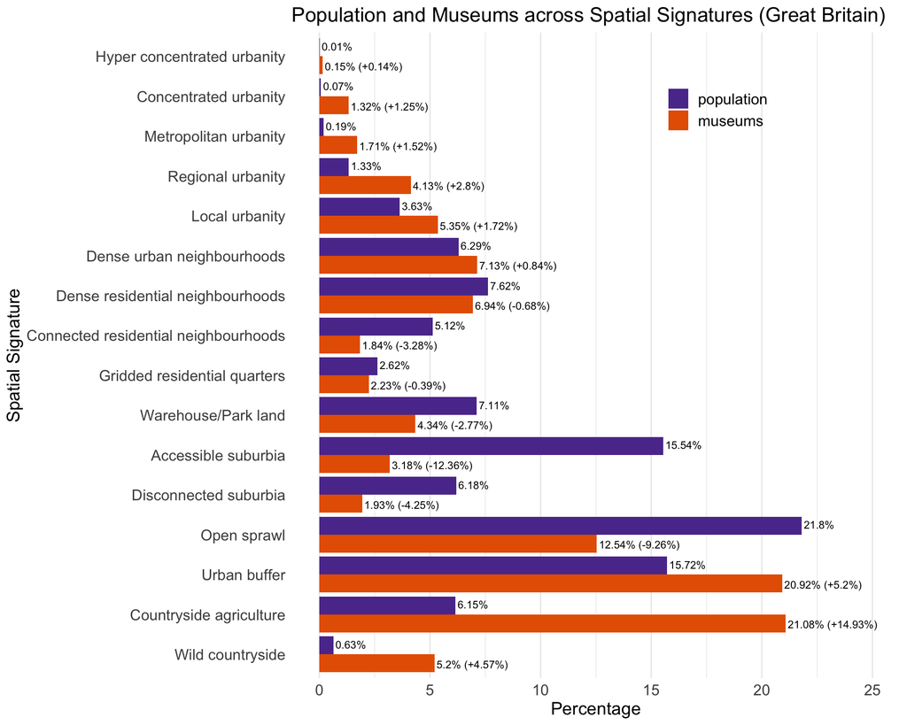

## Museums by Region

|  | Country/Region | Urban Population (millions) | Urban Population (%) | Urban Area (sqkm) | Urban Area (%) | Urban Museums (N) | Urban Museums (%) | Urban Museums (per 100k residents) | Urban Z-score (per 100k residents) | Urban Museums (per 100 sqkm) | Urban Z-score (per 100 sqkm) | Rural Population (millions) | Rural Population (%) | Rural Area (sqkm) | Rural Area (%) | Rural Museums (N) | Rural Museums (%) | Rural Museums (per 100k residents) | Rural Z-score (per 100k residents) | Rural Museums (per 100 sqkm) | Rural Z-score (per 100 sqkm) |
| --- | --- | --- | --- | --- | --- | --- | --- | --- | --- | --- | --- | --- | --- | --- | --- | --- | --- | --- | --- | --- | --- |
| 1 | Northern Ireland | 1.05 | 54.8 | 739 | 5.2 | 52 | 54.7 | 4.96 | [-0.55] | 7.04 | [0.94] | 0.86 | 45.2 | 13383 | 94.8 | 43 | 45.3 | 4.98 | [-0.55] | 0.32 | [-0.92] |
| 2 | Scotland | 3.92 | 72 | 2327 | 3 | 215 | 41 | 5.49 | [-0.47] | 9.24 | [1.55] | 1.52 | 28 | 74590 | 97 | 309 | 59 | 20.27 | [2] | 0.41 | [-0.89] |
| 3 | Wales | 2.21 | 70.5 | 2215 | 10.7 | 79 | 38.5 | 3.57 | [-0.79] | 3.57 | [-0.02] | 0.93 | 29.5 | 18550 | 89.3 | 126 | 61.5 | 13.58 | [0.88] | 0.68 | [-0.82] |
| 4 | England | 47.61 | 83.4 | 22713 | 17.9 | 1577 | 62.3 | 3.31 | [-0.83] | 6.94 | [0.91] | 9.49 | 16.6 | 104314 | 82.1 | 955 | 37.7 | 10.06 | [0.3] | 0.92 | [-0.75] |
| 5 | North East | 2.21 | 82.4 | 1218 | 14.5 | 62 | 57.9 | 2.81 | [-0.93] | 5.09 | [0.07] | 0.47 | 17.6 | 7199 | 85.5 | 45 | 42.1 | 9.54 | [0.57] | 0.63 | [-0.63] |
| 6 | North West | 6.79 | 90.3 | 3273 | 23.9 | 183 | 72.9 | 2.7 | [-0.96] | 5.59 | [0.15] | 0.73 | 9.7 | 10399 | 76.1 | 68 | 27.1 | 9.35 | [0.53] | 0.65 | [-0.63] |
| 7 | Yorks &amp; Humber | 4.62 | 83.4 | 2656 | 17.6 | 157 | 68.9 | 3.4 | [-0.8] | 5.91 | [0.2] | 0.92 | 16.6 | 12459 | 82.4 | 71 | 31.1 | 7.72 | [0.16] | 0.57 | [-0.64] |
| 8 | East Midlands | 3.64 | 73.8 | 2400 | 15.6 | 111 | 48.7 | 3.05 | [-0.88] | 4.62 | [0] | 1.29 | 26.2 | 12973 | 84.4 | 117 | 51.3 | 9.05 | [0.46] | 0.9 | [-0.59] |
| 9 | West Midlands | 5.14 | 85.5 | 2085 | 16.5 | 158 | 66.9 | 3.07 | [-0.88] | 7.58 | [0.46] | 0.87 | 14.5 | 10540 | 83.5 | 78 | 33.1 | 8.92 | [0.43] | 0.74 | [-0.62] |
| 10 | East of England | 4.64 | 72.5 | 3036 | 16.1 | 174 | 50.9 | 3.75 | [-0.72] | 5.73 | [0.17] | 1.76 | 27.5 | 15774 | 83.9 | 168 | 49.1 | 9.55 | [0.57] | 1.07 | [-0.57] |

[output cut: 4 more lines]

#### Figures for only houses (large, medium, or small)

|  | Country/Region | Urban Population (millions) | Urban Population (%) | Urban Area (sqkm) | Urban Area (%) | Urban Museums (N) | Urban Museums (%) | Urban Museums (per 100k residents) | Urban Z-score (per 100k residents) | Urban Museums (per 100 sqkm) | Urban Z-score (per 100 sqkm) | Rural Population (millions) | Rural Population (%) | Rural Area (sqkm) | Rural Area (%) | Rural Museums (N) | Rural Museums (%) | Rural Museums (per 100k residents) | Rural Z-score (per 100k residents) | Rural Museums (per 100 sqkm) | Rural Z-score (per 100 sqkm) |
| --- | --- | --- | --- | --- | --- | --- | --- | --- | --- | --- | --- | --- | --- | --- | --- | --- | --- | --- | --- | --- | --- |
| 1 | Northern Ireland | 1.05 | 54.8 | 739 | 5.2 | 1 | 9.1 | 0.1 | [-0.92] | 0.14 | [-0.59] | 0.86 | 45.2 | 13383 | 94.8 | 10 | 90.9 | 1.16 | [-0.05] | 0.07 | [-0.86] |
| 2 | Scotland | 3.92 | 72 | 2327 | 3 | 13 | 19.7 | 0.33 | [-0.73] | 0.56 | [1.35] | 1.52 | 28 | 74590 | 97 | 53 | 80.3 | 3.48 | [1.84] | 0.07 | [-0.88] |
| 3 | Wales | 2.21 | 70.5 | 2215 | 10.7 | 8 | 34.8 | 0.36 | [-0.71] | 0.36 | [0.45] | 0.93 | 29.5 | 18550 | 89.3 | 15 | 65.2 | 1.62 | [0.32] | 0.08 | [-0.83] |
| 4 | England | 47.61 | 83.4 | 22713 | 17.9 | 137 | 36.9 | 0.29 | [-0.77] | 0.6 | [1.55] | 9.49 | 16.6 | 104314 | 82.1 | 234 | 63.1 | 2.46 | [1.01] | 0.22 | [-0.18] |
| 5 | North East | 2.21 | 82.4 | 1218 | 14.5 | 2 | 33.3 | 0.09 | [-0.94] | 0.16 | [-0.43] | 0.47 | 17.6 | 7199 | 85.5 | 4 | 66.7 | 0.85 | [-0.33] | 0.06 | [-0.6] |
| 6 | North West | 6.79 | 90.3 | 3273 | 23.9 | 16 | 37.2 | 0.24 | [-0.83] | 0.49 | [0.06] | 0.73 | 9.7 | 10399 | 76.1 | 27 | 62.8 | 3.71 | [2.01] | 0.26 | [-0.29] |
| 7 | Yorks &amp; Humber | 4.62 | 83.4 | 2656 | 17.6 | 11 | 32.4 | 0.24 | [-0.82] | 0.41 | [-0.05] | 0.92 | 16.6 | 12459 | 82.4 | 23 | 67.6 | 2.5 | [1.02] | 0.18 | [-0.4] |
| 8 | East Midlands | 3.64 | 73.8 | 2400 | 15.6 | 8 | 24.2 | 0.22 | [-0.84] | 0.33 | [-0.17] | 1.29 | 26.2 | 12973 | 84.4 | 25 | 75.8 | 1.93 | [0.56] | 0.19 | [-0.39] |
| 9 | West Midlands | 5.14 | 85.5 | 2085 | 16.5 | 22 | 52.4 | 0.43 | [-0.67] | 1.06 | [0.94] | 0.87 | 14.5 | 10540 | 83.5 | 20 | 47.6 | 2.29 | [0.85] | 0.19 | [-0.4] |
| 10 | East of England | 4.64 | 72.5 | 3036 | 16.1 | 11 | 27.5 | 0.24 | [-0.82] | 0.36 | [-0.13] | 1.76 | 27.5 | 15774 | 83.9 | 29 | 72.5 | 1.65 | [0.33] | 0.18 | [-0.4] |

[output cut: 4 more lines]

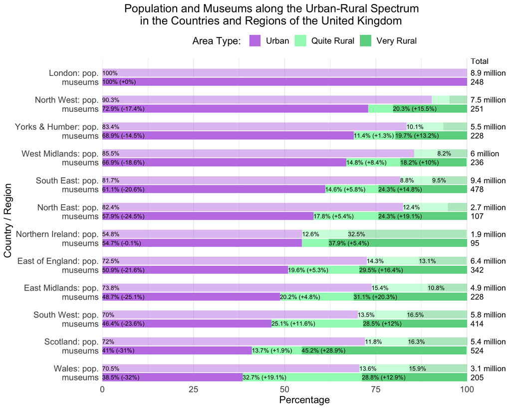

## Museum Types in Urban and Rural Areas

|  | ruc_composite_3_fold | subject_specific | total_museums | museums_percentage | total_population | total_area_sqkm | population_percentage | area_percentage | population_millions | museums_per_100k_people | museums_per_100sqkm | z_score_per_100k_people | z_score_per_100sqkm |
| --- | --- | --- | --- | --- | --- | --- | --- | --- | --- | --- | --- | --- | --- |
| 1 | Urban | Archaeology-Greek_and_Egyptian | 4 | 100 | 54785919 | 27994 | 81 | 11.7 | 54.79 | 0.01 | 0.01 | [-0.26] | [-0.18] |
| 2 | Urban | Archaeology-Medieval | 3 | 27 | 54785919 | 27994 | 81 | 11.7 | 54.79 | 0.01 | 0.01 | [-0.26] | [-0.21] |
| 3 | Urban | Archaeology-Mixed | 10 | 71 | 54785919 | 27994 | 81 | 11.7 | 54.79 | 0.02 | 0.04 | [-0.22] | [0.01] |
| 4 | Urban | Archaeology-Other | 1 | 50 | 54785919 | 27994 | 81 | 11.7 | 54.79 | 0 | 0 | [-0.27] | [-0.27] |
| 5 | Urban | Archaeology-Prehistory | 5 | 26 | 54785919 | 27994 | 81 | 11.7 | 54.79 | 0.01 | 0.02 | [-0.25] | [-0.14] |
| 6 | Urban | Archaeology-Roman | 17 | 45 | 54785919 | 27994 | 81 | 11.7 | 54.79 | 0.03 | 0.06 | [-0.18] | [0.23] |
| 7 | Urban | Arts-Ceramics | 10 | 62 | 54785919 | 27994 | 81 | 11.7 | 54.79 | 0.02 | 0.04 | [-0.22] | [0.01] |
| 8 | Urban | Arts-Costume_and_textiles | 8 | 73 | 54785919 | 27994 | 81 | 11.7 | 54.79 | 0.01 | 0.03 | [-0.23] | [-0.05] |
| 9 | Urban | Arts-Crafts | 4 | 100 | 54785919 | 27994 | 81 | 11.7 | 54.79 | 0.01 | 0.01 | [-0.26] | [-0.18] |
| 10 | Urban | Arts-Design | 5 | 62 | 54785919 | 27994 | 81 | 11.7 | 54.79 | 0.01 | 0.02 | [-0.25] | [-0.14] |

[output cut: 271 more lines]

|  | ruc_composite_3_fold | subject_broad | total_museums | museums_percentage | total_population | total_area_sqkm | population_percentage | area_percentage | population_millions | museums_per_100k_people | museums_per_100sqkm | z_score_per_100k_people | z_score_per_100sqkm |
| --- | --- | --- | --- | --- | --- | --- | --- | --- | --- | --- | --- | --- | --- |
| 1 | Urban | Archaeology | 40 | 45 | 54785919 | 27994 | 81 | 11.7 | 54.79 | 0.07 | 0.14 | [-0.47] | [-0.06] |
| 2 | Urban | Arts | 211 | 82 | 54785919 | 27994 | 81 | 11.7 | 54.79 | 0.39 | 0.75 | [-0.05] | [2.26] |
| 3 | Urban | Belief_and_identity | 73 | 70 | 54785919 | 27994 | 81 | 11.7 | 54.79 | 0.13 | 0.26 | [-0.39] | [0.39] |
| 4 | Urban | Buildings | 206 | 38 | 54785919 | 27994 | 81 | 11.7 | 54.79 | 0.38 | 0.74 | [-0.06] | [2.19] |
| 5 | Urban | Communications | 7 | 58 | 54785919 | 27994 | 81 | 11.7 | 54.79 | 0.01 | 0.03 | [-0.55] | [-0.5] |
| 6 | Urban | Food_and_drink | 7 | 47 | 54785919 | 27994 | 81 | 11.7 | 54.79 | 0.01 | 0.03 | [-0.55] | [-0.5] |
| 7 | Urban | Industry_and_manufacture | 105 | 70 | 54785919 | 27994 | 81 | 11.7 | 54.79 | 0.19 | 0.38 | [-0.31] | [0.82] |
| 8 | Urban | Leisure_and_sport | 62 | 70 | 54785919 | 27994 | 81 | 11.7 | 54.79 | 0.11 | 0.22 | [-0.42] | [0.24] |
| 9 | Urban | Local_Histories | 412 | 53 | 54785919 | 27994 | 81 | 11.7 | 54.79 | 0.75 | 1.47 | [0.45] | [4.98] |
| 10 | Urban | Medicine_and_health | 33 | 97 | 54785919 | 27994 | 81 | 11.7 | 54.79 | 0.06 | 0.12 | [-0.49] | [-0.15] |

[output cut: 51 more lines]

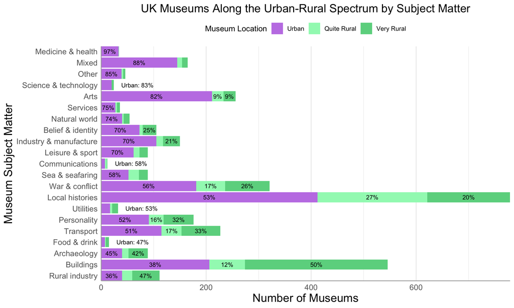

|  | ruc_composite_3_fold | era | total_museums | museums_percentage | total_population | total_area_sqkm | population_percentage | area_percentage | population_millions | museums_per_100k_people | museums_per_100sqkm | z_score_per_100k_people | z_score_per_100sqkm |
| --- | --- | --- | --- | --- | --- | --- | --- | --- | --- | --- | --- | --- | --- |
| 1 | Urban | 1900-1944 | 243 | 72 | 54785919 | 27994 | 81 | 11.7 | 54.79 | 0.44 | 0.87 | [-0.68] | [0.07] |
| 2 | Urban | 1945-1989 | 812 | 50 | 54785919 | 27994 | 81 | 11.7 | 54.79 | 1.48 | 2.9 | [-0.26] | [2.22] |
| 3 | Urban | 1990-present | 663 | 58 | 54785919 | 27994 | 81 | 11.7 | 54.79 | 1.21 | 2.37 | [-0.37] | [1.66] |
| 4 | Urban | pre-1900 | 205 | 90 | 54785919 | 27994 | 81 | 11.7 | 54.79 | 0.37 | 0.73 | [-0.7] | [-0.07] |
| 5 | Quite Rural | 1900-1944 | 44 | 13 | 6228473 | 23354 | 9.2 | 9.8 | 6.23 | 0.71 | 0.19 | [-0.57] | [-0.65] |
| 6 | Quite Rural | 1945-1989 | 271 | 17 | 6228473 | 23354 | 9.2 | 9.8 | 6.23 | 4.35 | 1.16 | [0.88] | [0.38] |
| 7 | Quite Rural | 1990-present | 201 | 17 | 6228473 | 23354 | 9.2 | 9.8 | 6.23 | 3.23 | 0.86 | [0.43] | [0.06] |
| 8 | Quite Rural | pre-1900 | 14 | 6 | 6228473 | 23354 | 9.2 | 9.8 | 6.23 | 0.22 | 0.06 | [-0.76] | [-0.78] |
| 9 | Very Rural | 1900-1944 | 52 | 15 | 6580969 | 187483 | 9.7 | 78.5 | 6.58 | 0.79 | 0.03 | [-0.54] | [-0.82] |
| 10 | Very Rural | 1945-1989 | 556 | 34 | 6580969 | 187483 | 9.7 | 78.5 | 6.58 | 8.45 | 0.3 | [2.51] | [-0.53] |

[output cut: 2 more lines]

|  | ruc_composite_3_fold | size | total_museums | museums_percentage | total_population | total_area_sqkm | population_percentage | area_percentage | population_millions | museums_per_100k_people | museums_per_100sqkm | z_score_per_100k_people | z_score_per_100sqkm |
| --- | --- | --- | --- | --- | --- | --- | --- | --- | --- | --- | --- | --- | --- |
| 1 | Urban | huge | 18 | 100 | 54785919 | 27994 | 81 | 11.7 | 54.79 | 0.03 | 0.06 | [-0.76] | [-0.68] |
| 2 | Urban | large | 332 | 68 | 54785919 | 27994 | 81 | 11.7 | 54.79 | 0.61 | 1.19 | [-0.54] | [0.45] |
| 3 | Urban | medium | 574 | 67 | 54785919 | 27994 | 81 | 11.7 | 54.79 | 1.05 | 2.05 | [-0.36] | [1.31] |
| 4 | Urban | small | 909 | 49 | 54785919 | 27994 | 81 | 11.7 | 54.79 | 1.66 | 3.25 | [-0.13] | [2.51] |
| 5 | Urban | unknown | 90 | 63 | 54785919 | 27994 | 81 | 11.7 | 54.79 | 0.16 | 0.32 | [-0.71] | [-0.42] |
| 6 | Quite Rural | large | 45 | 9 | 6228473 | 23354 | 9.2 | 9.8 | 6.23 | 0.72 | 0.19 | [-0.49] | [-0.55] |
| 7 | Quite Rural | medium | 98 | 11 | 6228473 | 23354 | 9.2 | 9.8 | 6.23 | 1.57 | 0.42 | [-0.16] | [-0.32] |
| 8 | Quite Rural | small | 367 | 20 | 6228473 | 23354 | 9.2 | 9.8 | 6.23 | 5.89 | 1.57 | [1.53] | [0.83] |
| 9 | Quite Rural | unknown | 20 | 14 | 6228473 | 23354 | 9.2 | 9.8 | 6.23 | 0.32 | 0.09 | [-0.65] | [-0.66] |
| 10 | Very Rural | large | 114 | 23 | 6580969 | 187483 | 9.7 | 78.5 | 6.58 | 1.73 | 0.06 | [-0.1] | [-0.68] |

[output cut: 3 more lines]

|  | ruc_composite_3_fold | governance_specific | total_museums | museums_percentage | total_population | total_area_sqkm | population_percentage | area_percentage | population_millions | museums_per_100k_people | museums_per_100sqkm | z_score_per_100k_people | z_score_per_100sqkm |
| --- | --- | --- | --- | --- | --- | --- | --- | --- | --- | --- | --- | --- | --- |
| 1 | Urban | English_Heritage | 25 | 48 | 54785919 | 27994 | 81 | 11.7 | 54.79 | 0.05 | 0.09 | [-0.55] | [-0.32] |
| 2 | Urban | Historic_Environment_Scotland | 6 | 29 | 54785919 | 27994 | 81 | 11.7 | 54.79 | 0.01 | 0.02 | [-0.58] | [-0.42] |
| 3 | Urban | Local_Authority | 574 | 81 | 54785919 | 27994 | 81 | 11.7 | 54.79 | 1.05 | 2.05 | [0.18] | [2.65] |
| 4 | Urban | National | 54 | 79 | 54785919 | 27994 | 81 | 11.7 | 54.79 | 0.1 | 0.19 | [-0.51] | [-0.16] |
| 5 | Urban | National_Trust | 45 | 24 | 54785919 | 27994 | 81 | 11.7 | 54.79 | 0.08 | 0.16 | [-0.52] | [-0.21] |
| 6 | Urban | National_Trust_for_Scotland | 8 | 31 | 54785919 | 27994 | 81 | 11.7 | 54.79 | 0.01 | 0.03 | [-0.57] | [-0.41] |
| 7 | Urban | Not_for_profit | 874 | 57 | 54785919 | 27994 | 81 | 11.7 | 54.79 | 1.6 | 3.12 | [0.57] | [4.28] |
| 8 | Urban | Other_Government | 2 | 33 | 54785919 | 27994 | 81 | 11.7 | 54.79 | 0 | 0.01 | [-0.58] | [-0.44] |
| 9 | Urban | Private | 171 | 35 | 54785919 | 27994 | 81 | 11.7 | 54.79 | 0.31 | 0.61 | [-0.36] | [0.47] |
| 10 | Urban | University | 90 | 94 | 54785919 | 27994 | 81 | 11.7 | 54.79 | 0.16 | 0.32 | [-0.46] | [0.03] |

[output cut: 22 more lines]

|  | ruc_composite_3_fold | governance_broad | total_museums | museums_percentage | total_population | total_area_sqkm | population_percentage | area_percentage | population_millions | museums_per_100k_people | museums_per_100sqkm | z_score_per_100k_people | z_score_per_100sqkm |
| --- | --- | --- | --- | --- | --- | --- | --- | --- | --- | --- | --- | --- | --- |
| 1 | Urban | Independent | 958 | 52 | 54785919 | 27994 | 81 | 11.7 | 54.79 | 1.75 | 3.42 | [0.22] | [3.4] |
| 2 | Urban | Local_Authority | 574 | 81 | 54785919 | 27994 | 81 | 11.7 | 54.79 | 1.05 | 2.05 | [-0.11] | [1.81] |
| 3 | Urban | National | 54 | 79 | 54785919 | 27994 | 81 | 11.7 | 54.79 | 0.1 | 0.19 | [-0.57] | [-0.33] |
| 4 | Urban | Other_Government | 2 | 33 | 54785919 | 27994 | 81 | 11.7 | 54.79 | 0 | 0.01 | [-0.61] | [-0.55] |
| 5 | Urban | Private | 171 | 35 | 54785919 | 27994 | 81 | 11.7 | 54.79 | 0.31 | 0.61 | [-0.46] | [0.15] |
| 6 | Urban | University | 90 | 94 | 54785919 | 27994 | 81 | 11.7 | 54.79 | 0.16 | 0.32 | [-0.54] | [-0.18] |
| 7 | Urban | Unknown | 74 | 44 | 54785919 | 27994 | 81 | 11.7 | 54.79 | 0.14 | 0.26 | [-0.55] | [-0.25] |
| 8 | Quite Rural | Independent | 333 | 18 | 6228473 | 23354 | 9.2 | 9.8 | 6.23 | 5.35 | 1.43 | [1.93] | [1.09] |
| 9 | Quite Rural | Local_Authority | 72 | 10 | 6228473 | 23354 | 9.2 | 9.8 | 6.23 | 1.16 | 0.31 | [-0.06] | [-0.2] |
| 10 | Quite Rural | National | 6 | 9 | 6228473 | 23354 | 9.2 | 9.8 | 6.23 | 0.1 | 0.03 | [-0.57] | [-0.53] |

[output cut: 10 more lines]

```

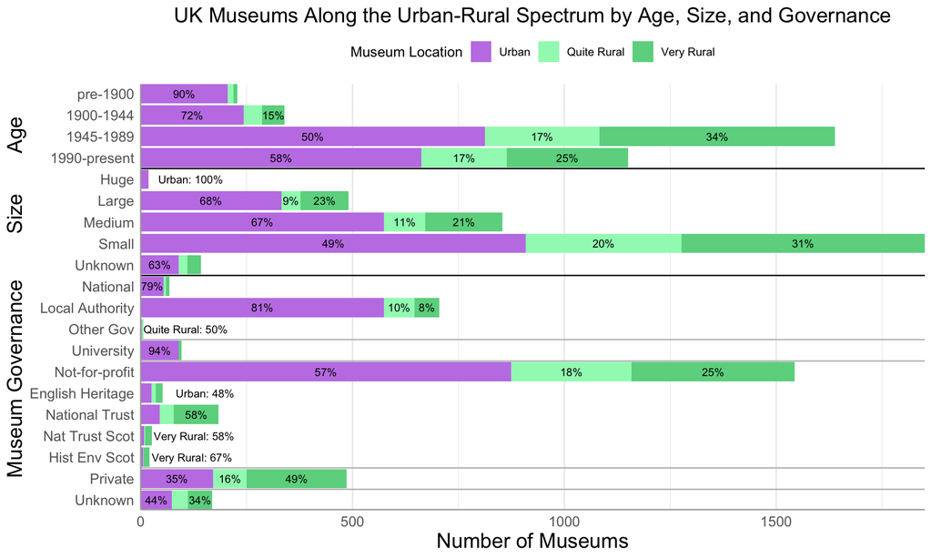

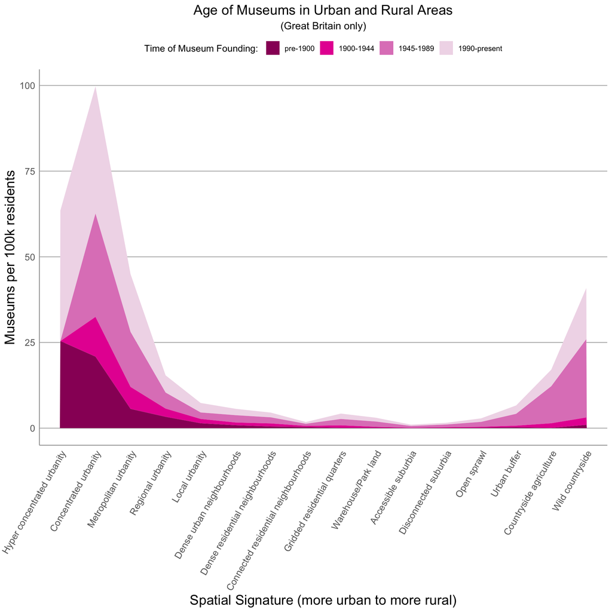